# PDH - Final Report

### Import Libraries

```python
import pandas as pd
import numpy as np
from IPython.display import display
import seaborn as sns
import dtale
import matplotlib.pyplot as plt
import math
```

### Read Data

```python
city_dict = pd.read_json("city_dict.json",typ='series')
city_codes = pd.DataFrame({'code':city_dict.index, 'city':city_dict.values})
discount_features = pd.read_csv("discount_features.csv", sep=',', header=0)
foot_fall = pd.read_csv("foot_fall.csv", sep=',', header=0)
sample_submission = pd.read_csv("sample_submission.csv", sep=',', header=0)
test_data = pd.read_csv("test_data.csv", sep=',', header=0)
train_data = pd.read_csv("train_data.csv", sep=',', header=0)
```

## Understand Data

### What's the shape ?

```python
dfs = {
    "train_data" : train_data,
    "test_data" : test_data,
    "city_codes" : city_codes,
    "discount_features" : discount_features,
    "foot_fall" : foot_fall
    }

line = "▒"*20

for name,df in dfs.items():
    print('{0} {1}.shape {2}'.format(line,name,line))
    display(df.shape)
```

```
▒▒▒▒▒▒▒▒▒▒▒▒▒▒▒▒▒▒▒▒ train_data.shape ▒▒▒▒▒▒▒▒▒▒▒▒▒▒▒▒▒▒▒▒
```

```
(22624345, 6)
```

```
▒▒▒▒▒▒▒▒▒▒▒▒▒▒▒▒▒▒▒▒ test_data.shape ▒▒▒▒▒▒▒▒▒▒▒▒▒▒▒▒▒▒▒▒
```

```
(773535, 6)
```

```
▒▒▒▒▒▒▒▒▒▒▒▒▒▒▒▒▒▒▒▒ city_codes.shape ▒▒▒▒▒▒▒▒▒▒▒▒▒▒▒▒▒▒▒▒
```

```
(10, 2)
```

```
▒▒▒▒▒▒▒▒▒▒▒▒▒▒▒▒▒▒▒▒ discount_features.shape ▒▒▒▒▒▒▒▒▒▒▒▒▒▒▒▒▒▒▒▒
```

```
(17277949, 4)
```

```
▒▒▒▒▒▒▒▒▒▒▒▒▒▒▒▒▒▒▒▒ foot_fall.shape ▒▒▒▒▒▒▒▒▒▒▒▒▒▒▒▒▒▒▒▒
```

```
(10, 1268)
```

### What are the features ?

```python
for name,df in dfs.items():
    print('{0} {1}.head(3) {2}'.format(line,name,line))
    display(df.head(3))
```

```
▒▒▒▒▒▒▒▒▒▒▒▒▒▒▒▒▒▒▒▒ train_data.head(3) ▒▒▒▒▒▒▒▒▒▒▒▒▒▒▒▒▒▒▒▒
```

|  | year | month | day | city | medicine | sales |
| --- | --- | --- | --- | --- | --- | --- |
| 0 | 2015 | 1 | 2 | 1 | 1 | 24.0 |
| 1 | 2015 | 1 | 2 | 1 | 2 | 144.0 |
| 2 | 2015 | 1 | 2 | 1 | 3 | 84.0 |

```
▒▒▒▒▒▒▒▒▒▒▒▒▒▒▒▒▒▒▒▒ test_data.head(3) ▒▒▒▒▒▒▒▒▒▒▒▒▒▒▒▒▒▒▒▒
```

|  | id | year | month | day | city | medicine |
| --- | --- | --- | --- | --- | --- | --- |
| 0 | 1 | 2018 | 7 | 1 | 1 | 1292 |
| 1 | 2 | 2018 | 7 | 1 | 1 | 1 |
| 2 | 3 | 2018 | 7 | 1 | 1 | 2 |

```
▒▒▒▒▒▒▒▒▒▒▒▒▒▒▒▒▒▒▒▒ city_codes.head(3) ▒▒▒▒▒▒▒▒▒▒▒▒▒▒▒▒▒▒▒▒
```

|  | code | city |
| --- | --- | --- |
| 0 | 4 | Mumbai |
| 1 | 5 | Delhi |
| 2 | 7 | Bangalore |

```
▒▒▒▒▒▒▒▒▒▒▒▒▒▒▒▒▒▒▒▒ discount_features.head(3) ▒▒▒▒▒▒▒▒▒▒▒▒▒▒▒▒▒▒▒▒
```

|  | date | city | medicine | discounted |
| --- | --- | --- | --- | --- |
| 0 | 2016-04-01 | 1 | 1 | 0 |
| 1 | 2016-04-01 | 1 | 2 | 0 |
| 2 | 2016-04-01 | 1 | 3 | 0 |

```
▒▒▒▒▒▒▒▒▒▒▒▒▒▒▒▒▒▒▒▒ foot_fall.head(3) ▒▒▒▒▒▒▒▒▒▒▒▒▒▒▒▒▒▒▒▒
```

|  | city | 2015-01-02 | 2015-01-03 | 2015-01-04 | 2015-01-05 | 2015-01-06 | 2015-01-07 | 2015-01-08 | 2015-01-09 | 2015-01-10 | ... | 2018-06-21 | 2018-06-22 | 2018-06-23 | 2018-06-24 | 2018-06-25 | 2018-06-26 | 2018-06-27 | 2018-06-28 | 2018-06-29 | 2018-06-30 |
| --- | --- | --- | --- | --- | --- | --- | --- | --- | --- | --- | --- | --- | --- | --- | --- | --- | --- | --- | --- | --- | --- |
| 0 | Ahmedabad | 9384.0 | 6808.0 | 8064.0 | 10248.0 | 11180.0 | 6876.0 | 6436.0 | 7104.0 | 5924.0 | ... | 9624.0 | 10476.0 | 9584.0 | 11940.0 | 13040.0 | 12144.0 | 10164.0 | 9784.0 | 10472.0 | 10040.0 |
| 1 | Bangalore | 16644.0 | 14640.0 | 15660.0 | 19056.0 | 19740.0 | 14280.0 | 12740.0 | 13480.0 | 11928.0 | ... | 12412.0 | 13392.0 | 11948.0 | 13860.0 | 16384.0 | 16192.0 | 12388.0 | 12124.0 | 13412.0 | 12172.0 |
| 2 | Chennai | 19544.0 | 13752.0 | 13736.0 | 19740.0 | 21604.0 | 12820.0 | 12244.0 | 11956.0 | 10508.0 | ... | 10420.0 | 11044.0 | 10320.0 | 11988.0 | 15248.0 | 15188.0 | 10596.0 | 9716.0 | 10776.0 | 10336.0 |

3 rows × 1268 columns

### What are the data types ?

```python
for name,df in dfs.items():
    print('{0} {1}.dtypes {2}'.format(line,name,line))
    display(df.dtypes)
```

```
▒▒▒▒▒▒▒▒▒▒▒▒▒▒▒▒▒▒▒▒ train_data.dtypes ▒▒▒▒▒▒▒▒▒▒▒▒▒▒▒▒▒▒▒▒
```

```
year          int64
month         int64
day           int64
city          int64
medicine      int64
sales       float64
dtype: object
```

```
▒▒▒▒▒▒▒▒▒▒▒▒▒▒▒▒▒▒▒▒ test_data.dtypes ▒▒▒▒▒▒▒▒▒▒▒▒▒▒▒▒▒▒▒▒
```

```
id          int64
year        int64
month       int64
day         int64
city        int64
medicine    int64
dtype: object
```

```
▒▒▒▒▒▒▒▒▒▒▒▒▒▒▒▒▒▒▒▒ city_codes.dtypes ▒▒▒▒▒▒▒▒▒▒▒▒▒▒▒▒▒▒▒▒
```

```
code     int64
city    object
dtype: object
```

```
▒▒▒▒▒▒▒▒▒▒▒▒▒▒▒▒▒▒▒▒ discount_features.dtypes ▒▒▒▒▒▒▒▒▒▒▒▒▒▒▒▒▒▒▒▒
```

```
date          object
city           int64
medicine       int64
discounted     int64
dtype: object
```

```
▒▒▒▒▒▒▒▒▒▒▒▒▒▒▒▒▒▒▒▒ foot_fall.dtypes ▒▒▒▒▒▒▒▒▒▒▒▒▒▒▒▒▒▒▒▒
```

```
city           object
2015-01-02    float64
2015-01-03    float64
2015-01-04    float64
2015-01-05    float64
               ...
2018-06-26    float64
2018-06-27    float64
2018-06-28    float64
2018-06-29    float64
2018-06-30    float64
Length: 1268, dtype: object
```

### Data type conversion

```python
test_data.columns
```

```
Index(['id', 'year', 'month', 'day', 'city', 'medicine'], dtype='object')
```

```python
for col in ['city', 'medicine']:
    train_data[col] = train_data[col].astype('category')
    test_data[col] = test_data[col].astype('category')
```

```python
for col in ['city', 'medicine']:
    discount_features[col] = discount_features[col].astype('category')

discount_features['date'] = discount_features['date'].astype('datetime64')
```

```python
for col in ['code', 'city']:
    city_codes[col] = city_codes[col].astype('category')
```

```python
foot_fall['city'] = foot_fall['city'].astype('category')
```

### Check NA and Null Values

```python
for name,df in dfs.items():
    display(df.isna().sum())
    display(df.isnull().sum())
```

```
year        0
month       0
day         0
city        0
medicine    0
sales       0
dtype: int64
```

```
year        0
month       0
day         0
city        0
medicine    0
sales       0
dtype: int64
```

```
id          0
year        0
month       0
day         0
city        0
medicine    0
dtype: int64
```

```
id          0
year        0
month       0
day         0
city        0
medicine    0
dtype: int64
```

```
code    0
city    0
dtype: int64
```

```
code    0
city    0
dtype: int64
```

```
date          0
city          0
medicine      0
discounted    0
dtype: int64
```

```
date          0
city          0
medicine      0
discounted    0
dtype: int64
```

```
city          0
2015-01-02    0
2015-01-03    0
2015-01-04    0
2015-01-05    0
             ..
2018-06-26    0
2018-06-27    0
2018-06-28    0
2018-06-29    0
2018-06-30    0
Length: 1268, dtype: int64
```

```
city          0
2015-01-02    0
2015-01-03    0
2015-01-04    0
2015-01-05    0
             ..
2018-06-26    0
2018-06-27    0
2018-06-28    0
2018-06-29    0
2018-06-30    0
Length: 1268, dtype: int64
```

### Feature Engineering

```python
train_data["date"] = pd.to_datetime(train_data[["year", "month", "day"]])
test_data["date"] = pd.to_datetime(test_data[["year", "month", "day"]])
test_data.drop(["year", "month", "day"],axis=1,inplace=True)
train_data.drop(["year", "month", "day"],axis=1,inplace=True)
```

### Univariate Analysis

```python
train_data.describe(include=np.number)
```

|  | sales |
| --- | --- |
| count | 2.262434e+07 |
| mean | 5.166032e+01 |
| std | 1.100297e+02 |
| min | -9.948000e+03 |
| 25% | 1.200000e+01 |
| 50% | 2.800000e+01 |
| 75% | 5.600000e+01 |
| max | 8.299200e+04 |

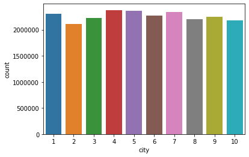

```python
sns.countplot(train_data['city'])
```

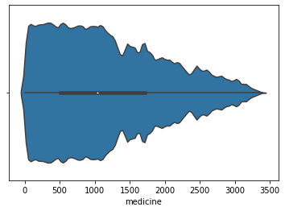

```python
sns.violinplot(train_data['medicine'])
```

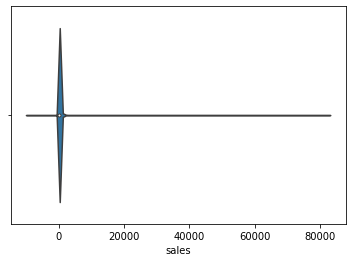

```python
sns.violinplot(train_data['sales'])
```

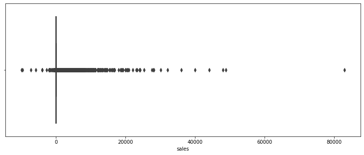

```python
plt.figure(figsize=(13, 5))
sns.boxplot(train_data['sales'])
```

### Conclusion

- Possible pressence of outlier values in sales values

### Bivariate Analysis

```python
tdmc1 = train_data[(train_data["date"] == '2018-01-30') & (train_data["sales"] < 400)]
tdmc1.shape
```

```
(25401, 4)
```

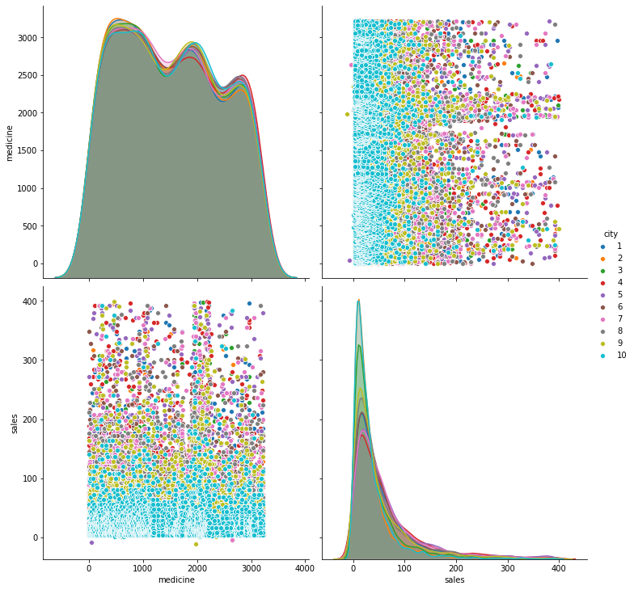

```python
sns.pairplot(tdmc1,hue="city",height=5)
```

```python
dttd = dtale.show(train_data)
```

```python
dttd.open_browser()
```

#### For medicine 100 and city 1

[figure not shown]

#### For medicine 100 and city 2

[figure not shown]

#### For medicine 200 and city 1

[figure not shown]

#### For medicine 200 and city 2

[figure not shown]

### Conclusion

- We notice that we have time series data of sales for each medicine and for each city
- Different medicine and cities have different levels of tends and randomness in the sales values
- We could treat each case a different forecasting model or
- We need to find out if there are any trend in cities or in the medicine over time
- We could aggregate or group sales values by cities or medicine whichever is appropriate on further analysis

# Solution 1

```python
# Read data
test_data = pd.read_csv("test_data.csv", sep=',', header=0)
train_data = pd.read_csv("train_data.csv", sep=',', header=0)

# Get train data for july month for all the years
train_jul = train_data[train_data['month'] == 7]

# Predict sales by taking mean of sales of previous years for a given city, medicine and day
def predictor(city,medicine,day):
    b = train_jul[(train_jul['city']==city)&(train_jul['medicine']==medicine)&(train_jul['day'] == day)].iloc[:,5].mean()
    return (0 if math.isnan(b) else round(b))

pred_list = []
# Prepare list of {'id':id,'sales':sales} values to convert into dataframe
for index, row in test_data.iterrows():
    pred_list.append({"id":row['id'],"sales":predictor(row['city'],row['medicine'],row['day'])})

# Convert list to dataframe
predictions = pd.DataFrame(pred_list)

# save to file
predictions.to_csv('sales_predictions_a_1.csv', index=False)
```

## Final Recomendation

- The average of the sales of previous years for a given day, month is a good estimator of sales for current year.

# Solution 2

```python
# Read data
test_data = pd.read_csv("test_data.csv", sep=',', header=0)
train_data = pd.read_csv("train_data.csv", sep=',', header=0)

# get train data for year 2018
train_2018 = train_data[train_data['year'] == 2018]
# get train data for last four months, i.e, month = 3,4,5,6 of 2018
train_2018_3456 = train_2018[(train_2018['month'] == 3) | (train_2018['month'] == 4) | (train_2018['month'] == 5) | (train_2018['month'] == 6)]

# Predict sales by taking mean of sales of last 4 moths of 2018 for a given city, medicine and day
def predictor(city,medicine,day):
    b = train_2018_3456[(train_2018_3456['city']==city)&(train_2018_3456['medicine']==medicine)&(train_2018_3456['day'] == day)].iloc[:,5].mean()
    return (0 if math.isnan(b) else round(b))

pred_list = []
# Prepare list of {'id':id,'sales':sales} values to convert into dataframe
for index, row in test_data.iterrows():
    pred_list.append({"id":row['id'],"sales":predictor(row['city'],row['medicine'],row['day'])})

# Convert list to dataframe
predictions = pd.DataFrame(pred_list)

# save to file
predictions.to_csv('sales_predictions_a_3_1.csv', index=False)
```

## Model Explaination in non-technical terms

- Get the sales values of last 4 months of 2018 for a give day, medicine and city.
- Take the mean of those values as prediction for the current month.

## Final Recomendation

- The average of the sales of previous months for a given day, medicine and city of current year is a good estimator of sales for current month.